# Fitness Device Analysis

James

4 July 2024

# Background

Using devices such as Jawbone Up, Nike FuelBand, and Fitbit it is now possible to collect a large amount of data about personal activity relatively inexpensively. These type of devices are part of the quantified self movement – a group of enthusiasts who take measurements about themselves regularly to improve their health, to find patterns in their behavior, or because they are tech geeks. One thing that people regularly do is quantify how much of a particular activity they do, but they rarely quantify how well they do it. In this project, your goal will be to use data from accelerometers on the belt, forearm, arm, and dumbell of 6 participants.

# Data Loading and Cross Validation Approach

The data is loaded, filtered and a holdout set created for cross validation which will be done with an 80:20 split. Care is taken not to allow individual windows to be represented in both the test and training sets in order to avoid overfitting.

```r
trainRaw <- read.csv("pml-training.csv", na.strings=c("NA", "", " "))
testRaw <- read.csv("pml-testing.csv", na.strings=c("NA", "", " "))

# filter out nas
trainRaw <- trainRaw[, colSums(is.na(trainRaw))==0]
testRaw <- testRaw[, colSums(is.na(testRaw))==0]

trainRaw$classe <- as.factor(trainRaw$classe)

set.seed(123)
unique_windows <- unique(trainRaw$num_window)
train_index <- createDataPartition(unique_windows, p=0.8, list=FALSE)

train_windows <- unique_windows[train_index]
test_windows <- unique_windows[-train_index]
train_data <- trainRaw %>% filter(num_window %in% train_windows)
test_data <- trainRaw %>% filter(num_window %in% test_windows)

# Remove metadata columns
train_data <- train_data[, -c(1:7)]
test_data <- test_data[, -c(1:7)]
```

# Exploratory Analysis

A histogram of the distribution of the dependent variable and a correlation plot of the independent variables are plotted below.

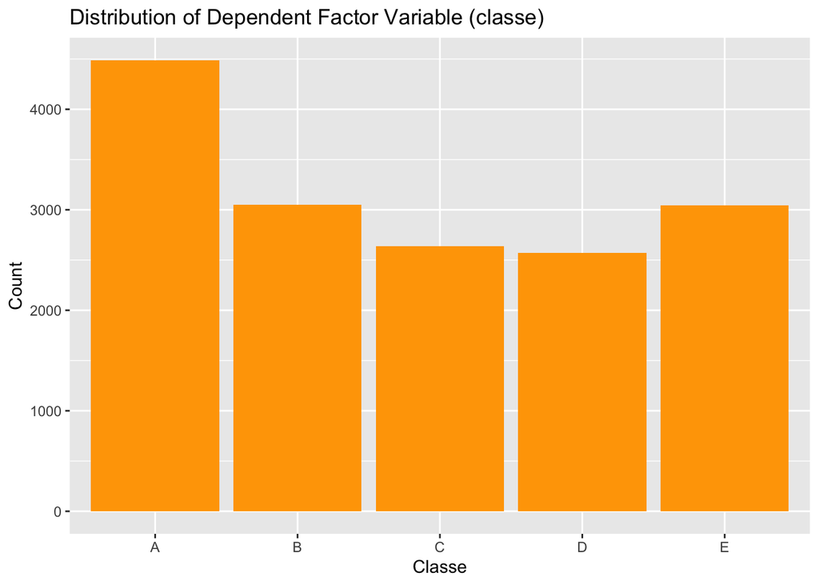

```r
# Histogram
ggplot(train_data, aes(x=classe)) +
  geom_bar(fill="orange") +
  labs(title = "Distribution of Dependent Factor Variable (classe)", x="Classe", y="Count")
```

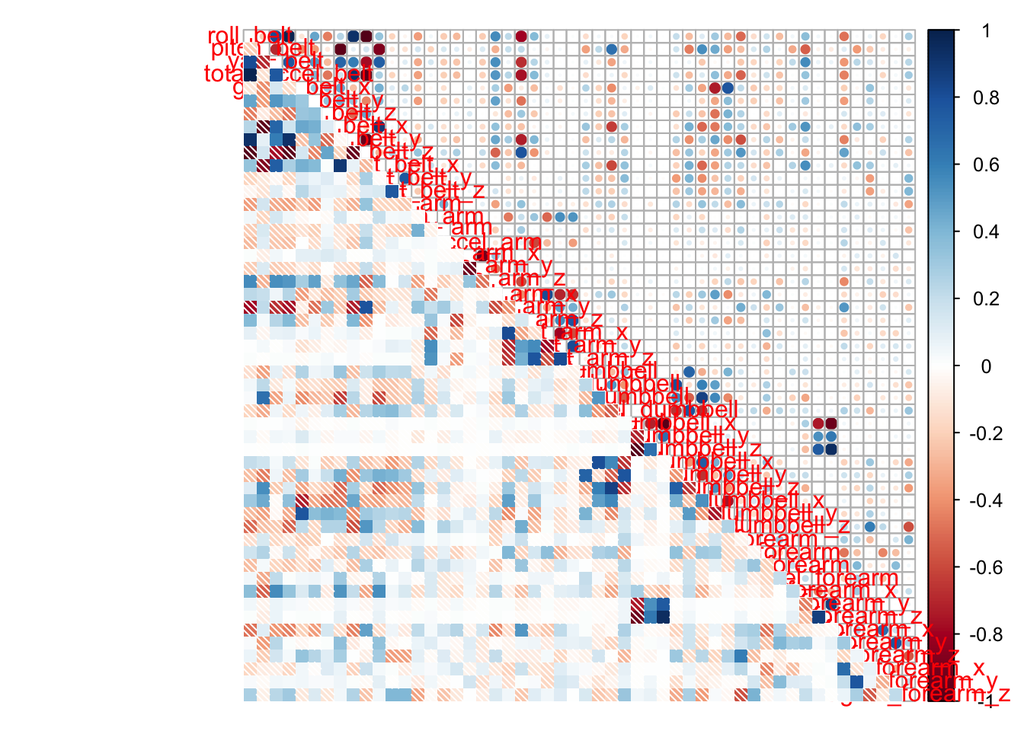

```r
corrplot.mixed(cor(train_data %>% select(-classe), use="complete.obs"), lower="shade")
```

# Modelling

Six models are trained: 1. Logistic 2. Naive Bayes 3. K-nearest neighbours 4. Random Forest 5. Support Vetcor Machine 6. Multilayer Perceptron

Confusion matrices and summaries are compiled for each:

```r
get_results <- function(model, testSet) {
  predicted <- predict(model, testSet)
  cm <- confusionMatrix(factor(predicted), factor(testSet$classe))
  print(cm)
  cm
}
```

Logistic Regression:

```r
train_control <- trainControl(method="cv", number=3)
logisticModel <- train(classe ~ ., data=train_data, method="multinom", trControl= train_control, trace=FALSE)
```

```r
confusionMatrix_LR <- get_results(logisticModel, test_data)
```

```
## Confusion Matrix and Statistics
##
##           Reference
## Prediction   A   B   C   D   E
##          A 870 110  80  57  18
##          B  99 368 142  50 113
##          C  45 130 403  60  35
##          D  55  50 120 441  60
##          E  23  92  39  38 336
##
## Overall Statistics
##
##                Accuracy : 0.6307
##                  95% CI : (0.6152, 0.646)
##     No Information Rate : 0.2848
##     P-Value [Acc > NIR] : < 2.2e-16
##
##                   Kappa : 0.5315
##
##  Mcnemar's Test P-Value : 2.686e-05
##
## Statistics by Class:
##
##                      Class: A Class: B Class: C Class: D Class: E
## Sensitivity            0.7967  0.49067   0.5140   0.6827  0.59786
## Specificity            0.9034  0.86900   0.9115   0.9106  0.94132
## Pos Pred Value         0.7665  0.47668   0.5988   0.6074  0.63636
## Neg Pred Value         0.9177  0.87524   0.8795   0.9340  0.93164
## Prevalence             0.2848  0.19562   0.2045   0.1685  0.14658
## Detection Rate         0.2269  0.09598   0.1051   0.1150  0.08764
## Detection Prevalence   0.2960  0.20136   0.1755   0.1894  0.13772
## Balanced Accuracy      0.8500  0.67983   0.7128   0.7966  0.76959
```

Naive Bayes :

```r
NaiveBayesModel <- naiveBayes(classe ~ ., data=train_data)
confusionMatrix_NB <- get_results(NaiveBayesModel, test_data)
```

```
## Confusion Matrix and Statistics
##
##           Reference
## Prediction   A   B   C   D   E
##          A 328  39  28   0   2
##          B  82 334 140  26  45
##          C 474 238 524 194  90
##          D 128  33  39 364 105
##          E  80 106  53  62 320
##
## Overall Statistics
##
##                Accuracy : 0.4877
##                  95% CI : (0.4718, 0.5037)
##     No Information Rate : 0.2848
##     P-Value [Acc > NIR] : < 2.2e-16
##
##                   Kappa : 0.3631
##
##  Mcnemar's Test P-Value : < 2.2e-16
##
## Statistics by Class:
##
##                      Class: A Class: B Class: C Class: D Class: E
## Sensitivity           0.30037  0.44533   0.6684  0.56347  0.56940
## Specificity           0.97484  0.90499   0.6734  0.90433  0.90801
## Pos Pred Value        0.82620  0.53270   0.3447  0.54410  0.51530
## Neg Pred Value        0.77771  0.87028   0.8876  0.91090  0.92468
## Prevalence            0.28482  0.19562   0.2045  0.16849  0.14658
## Detection Rate        0.08555  0.08712   0.1367  0.09494  0.08346
## Detection Prevalence  0.10355  0.16354   0.3965  0.17449  0.16197
## Balanced Accuracy     0.63760  0.67516   0.6709  0.73390  0.73870
```

K-Nearest Neighbours:

```r
KNNModel <- train(classe ~ ., data=train_data, method="knn", tuneGrid=expand.grid(k=5))
confusionMatrix_KNN <- get_results(KNNModel, test_data)
```

```
## Confusion Matrix and Statistics
##
##           Reference
## Prediction    A    B    C    D    E
##          A 1008  117   26   24    5
##          B   30  432   56   13   79
##          C   19   68  579   77   27
##          D   26   60   58  511   71
##          E    9   73   65   21  380
##
## Overall Statistics
##
##                Accuracy : 0.759
##                  95% CI : (0.7451, 0.7725)
##     No Information Rate : 0.2848
##     P-Value [Acc > NIR] : < 2.2e-16
##
##                   Kappa : 0.6939
##
##  Mcnemar's Test P-Value : < 2.2e-16
##
## Statistics by Class:
##
##                      Class: A Class: B Class: C Class: D Class: E
## Sensitivity            0.9231   0.5760   0.7385   0.7910  0.67616
## Specificity            0.9373   0.9423   0.9374   0.9326  0.94866
## Pos Pred Value         0.8542   0.7082   0.7519   0.7039  0.69343
## Neg Pred Value         0.9683   0.9014   0.9331   0.9566  0.94461
## Prevalence             0.2848   0.1956   0.2045   0.1685  0.14658
## Detection Rate         0.2629   0.1127   0.1510   0.1333  0.09911
## Detection Prevalence   0.3078   0.1591   0.2008   0.1894  0.14293
## Balanced Accuracy      0.9302   0.7591   0.8379   0.8618  0.81241
```

Random Forest:

```r
randomForestModel <- randomForest(classe ~ ., data=train_data)
confusionMatrix_RF <- get_results(randomForestModel, test_data)
```

```
## Confusion Matrix and Statistics
##
##           Reference
## Prediction    A    B    C    D    E
##          A 1088   32    0    0    0
##          B    4  696   88    0    6
##          C    0   20  678   50   15
##          D    0    2   12  592   10
##          E    0    0    6    4  531
##
## Overall Statistics
##
##                Accuracy : 0.9351
##                  95% CI : (0.9268, 0.9427)
##     No Information Rate : 0.2848
##     P-Value [Acc > NIR] : < 2.2e-16
##
##                   Kappa : 0.9176
##
##  Mcnemar's Test P-Value : NA
##
## Statistics by Class:
##
##                      Class: A Class: B Class: C Class: D Class: E
## Sensitivity            0.9963   0.9280   0.8648   0.9164   0.9448
## Specificity            0.9883   0.9682   0.9721   0.9925   0.9969
## Pos Pred Value         0.9714   0.8766   0.8886   0.9610   0.9815
## Neg Pred Value         0.9985   0.9822   0.9655   0.9832   0.9906
## Prevalence             0.2848   0.1956   0.2045   0.1685   0.1466
## Detection Rate         0.2838   0.1815   0.1768   0.1544   0.1385
## Detection Prevalence   0.2921   0.2071   0.1990   0.1607   0.1411
## Balanced Accuracy      0.9923   0.9481   0.9185   0.9544   0.9709
```

Support Vector Machine:

```r
SVMModel <- svm(classe ~ ., data=train_data, kernel="radial")
confusionMatrix_SVM <- get_results(SVMModel, test_data)
```

```
## Confusion Matrix and Statistics
##
##           Reference
## Prediction    A    B    C    D    E
##          A 1088   84   20    9    0
##          B    0  580   67    0   11
##          C    4   61  642   88   51
##          D    0    9   25  549   48
##          E    0   16   30    0  452
##
## Overall Statistics
##
##                Accuracy : 0.8636
##                  95% CI : (0.8523, 0.8743)
##     No Information Rate : 0.2848
##     P-Value [Acc > NIR] : < 2.2e-16
##
##                   Kappa : 0.8263
##
##  Mcnemar's Test P-Value : NA
##
## Statistics by Class:
##
##                      Class: A Class: B Class: C Class: D Class: E
## Sensitivity            0.9963   0.7733   0.8189   0.8498   0.8043
## Specificity            0.9588   0.9747   0.9331   0.9743   0.9859
## Pos Pred Value         0.9059   0.8815   0.7589   0.8700   0.9076
## Neg Pred Value         0.9985   0.9465   0.9525   0.9697   0.9670
## Prevalence             0.2848   0.1956   0.2045   0.1685   0.1466
## Detection Rate         0.2838   0.1513   0.1674   0.1432   0.1179
## Detection Prevalence   0.3132   0.1716   0.2207   0.1646   0.1299
## Balanced Accuracy      0.9776   0.8740   0.8760   0.9121   0.8951
```

Multi-layer Perceptron:

```r
MLPModel <- train(classe ~ ., data = train_data, method = "nnet", trace = FALSE)
confusionMatrix_MLP <- get_results(MLPModel, test_data)
```

```
## Confusion Matrix and Statistics
##
##           Reference
## Prediction   A   B   C   D   E
##          A 699 236 245 130 103
##          B 374 463 511 502 437
##          C   1   0   1   1   0
##          D   0   0   0   0   0
##          E  18  51  27  13  22
##
## Overall Statistics
##
##                Accuracy : 0.3091
##                  95% CI : (0.2945, 0.324)
##     No Information Rate : 0.2848
##     P-Value [Acc > NIR] : 0.0005087
##
##                   Kappa : 0.1064
##
##  Mcnemar's Test P-Value : < 2.2e-16
##
## Statistics by Class:
##
##                      Class: A Class: B  Class: C Class: D Class: E
## Sensitivity            0.6401   0.6173 0.0012755   0.0000 0.039146
## Specificity            0.7396   0.4086 0.9993443   1.0000 0.966687
## Pos Pred Value         0.4947   0.2024 0.3333333      NaN 0.167939
## Neg Pred Value         0.8377   0.8145 0.7956147   0.8315 0.854172
## Prevalence             0.2848   0.1956 0.2044862   0.1685 0.146583
## Detection Rate         0.1823   0.1208 0.0002608   0.0000 0.005738
## Detection Prevalence   0.3685   0.5965 0.0007825   0.0000 0.034168
## Balanced Accuracy      0.6899   0.5129 0.5003099   0.5000 0.502916
```

# Results

The accuracy, 95% confidence intervals and expected out of sample errors for each model are tabulated below.

```r
results <- list(
  LogisticRegression = confusionMatrix_LR,
  NaiveBayes = confusionMatrix_NB,
  KNN = confusionMatrix_KNN,
  RandomForest = confusionMatrix_RF,
  SVM = confusionMatrix_SVM,
  MLP = confusionMatrix_MLP
)

# out of sample error calculation
calculate_error <- function(cm) {
  1 - sum(diag(cm$table)) / sum(cm$table)
}

summary <- data.frame(
  Model = names(results),
  Accuracy = sapply(results, function(cm) cm$overall['Accuracy']),
  Error = sapply(results, calculate_error),
  LowerCI = sapply(results, function(cm) cm$overall['AccuracyLower']),
  UpperCI = sapply(results, function(cm) cm$overall['AccuracyUpper'])
)

kable(summary, format = "markdown", row.names = FALSE, col.names = c("Model", "Accuracy", "Error", "Lower 95% CI", "Upper 95% CI"))
```

[output not shown]

# Analysis

From the above summary we can see that the random forest has by far the best accuracy with the smallest expected out of sample error.

# Predictions

Finally we calculate predictions for the test set using the random forest model:

```r
predictions <- predict(randomForestModel, testRaw)
print(predictions)
```

```
##  1  2  3  4  5  6  7  8  9 10 11 12 13 14 15 16 17 18 19 20
##  B  A  B  A  A  E  D  B  A  A  B  C  B  A  E  E  A  B  B  B
## Levels: A B C D E
```